# Project Report

San Nguyen

2024-10-10

### Exploring Body Mass Index: Unveiling key predictors and sociodemographic sensitivity

#### *By Mazen Alhaffar, San Nguyen, and Rohitha Sai Kothapalli

#### **I. Introduction:**

**1. Patients:** BMI offers a low-cost assessment to quickly update patients’ health status. Patients can utilize this model to adjust nutrients, meal plans, and exercise routines at different life stages.

**2. Insurance Industry:** Insurance companies can gain insight from customers regarding health risks associated with obesity to offer more tailored insurance plans and develop incentive programs.

**3. Healthcare providers:** Healthcare providers can use this approach to evaluate health risks and tailor affordable treatments, enhancing healthcare management.

**4. Public health initiatives:** Public health organizations can rely on this model to target at-risk communities and create health strategies to prevent and reduce obesity.

**Research questions:** The central research question of this project explores how socio-demographic factors, including GDP, urbanization rate, human capital index, population, year, and globalization index, influence body mass index (BMI).

#### **II. Literature Review:**

In this literature review, we seeks to gather insightful articles to gain a comprehensive understanding of BMI measurement and the complex relationship between these factors and BMI. Valuable perspectives were gained through articles along with various variables which analyze how demographic factors interact with BMI, contributing to a comprehensive analysis of BMI’s demographic sensitivity.

- **Physiology, Body Mass Index:** Asia Zierle-Ghosh and Arif Jan’s article summarizes the BMIbenchmark for different classes of weight determined by the World Health Organization (WHO) and the Centers for Disease Control and Prevention (CDC). Using this benchmark as their basis, they elaborated on the issues surrounding BMI as a reliable measure, as it fails to calculate body fat percentage. This leads to miscalculating BMI of people with lean or bulky body mass. Moreover, it neglects to measure the abdominal obesity in the body, a major factor when it comes to high morbidity and mortality rates. More importantly, BMI fails to take into account the difference in body size between men and women, meaning BMI is lacking when it comes to different gender groups. Despite these facts, it has been proven that an increased BMI leads to a higher risk of developing several diseases, namely cancer, diabetes, and hypertension. This article helps us understand the shortcomings of BMI as a valid measure to predict diseases, laying the groundwork to answer our research question, and providing insight on the practical uses of the measure.
- **Factors affecting BMI; Assessment of the effect of sociodemographic factors on BMI In the population of Ghulam Mohammad Abad Faisalabad:** The study carried out by Dr. Abdul Sattar, Dr. Shahbaz Baig, Dr. Naveed ur Rehman, Dr. Badar Bashir provided a comprehensive understanding about the impact of sociodemographic variables, including age, marital status, income, location on BMI. This study indicated that income and age have a positive correlation with BMI while the figure for females tends to be higher than that of males. This result aligns closely with our central research question to investigate the sensitivity of demographic factors on BMI. Additionally, this study explored further lifestyle factors on BMI such as working hours, sleeping patterns, physical activity, smoking status which were significantly associated with BMI, whereupon suggesting tailored health interventions to manage and reduce obesity among different populations. These findings highlight interaction of demographic factors with BMI and emphasize the need to address lifestyle and additional predictors to enhance our analysis.
- **What use is the BMI? Archives of Disease in Childhood:** This article, written by D.M.B Hall and T.J. Cole, delves into the use of BMI to reduce obesity among children, exploring the methodologies that are used to identify early obesity signs and help communities measure and control increasing rates. Furthermore, the author uses centile-based definitions to illustrate the metric different countries use to measure overweight cases. Two approaches were presented to determine the validity of body fat measures, the first is physicochemical methods, which checks the amount of body water, and the second is imaging which measures the fat mass in the body. Nevertheless, the article also explores the pitfalls in the BMI metric, where various factors could affect the results, especially because the measure is correlated with body fat. This article enriched our understanding of BMI use when it comes to the specific age group of children, a group where accurately applying BMI principles is particularly challenging.
- **Gender Differences in the BMI-Income Relationship:** (Instrumental Variable Strategy) Edwards et al used genetic variants from the HUNT study as instruments to address endogeneity. The study finds a significant relationship between BMI and income for women but inconclusive results for men. For women, each 1-unit increase in BMI is associated with a 2% reduction in income. Specifically, the IV model using a weighted genetic risk score (GRS) shows a coefficient of-0.02 for females. The IV models used GRS based on 97 SNPs associated with BMI. The F-statistics for the instruments were well above 10, indicating strong relevance. For women, the weighted GRS IV model produced a coefficient of-0.020, suggesting a strong negative effect of BMI on income. For men, however, the IV models showed no significant effect on income, with results varying based on the instruments used. The study included 50,910 participants under the age of 67. For men, the highest mean income was found among those classified as overweight, while for women, those with normal weight had the highest mean income. Obese women earned significantly less.
- **The Association Between Physical Activity and Body Mass Index:** The study highlights that obesity significantly influences the PA-BMI relationship. In non-obese individuals, PA’s impact on BMI is minimal, while in obese individuals, the relationship is much stronger, particularly for vigorous PA. Hemmingsson and Ekelund conducted a study to explore this relationship using objective PA measurements in a diverse sample, including severely obese individuals and non-obese controls. PA was measured using accelerometers over seven days, capturing six categories: sedentary time, light PA, moderate PA, vigorous PA, total activity counts per day, and steps per day. In non-obese participants, the association between PA and BMI was weak.This suggests that obesity may act as a barrier to PA, creating a cycle where lower PA leads to higher BMI, which further reduces PA.

In conclusion, literature review establishes a fundamental foundation into BMI metrics and analyzes important factors that correlate with BMI. With the integration of lifestyle factors, we aim to seek additional data to support our multiple regression analysis, allowing us to examine these diverse predictors comprehensively and accurately.

#### **III. Data, Data Sources, and Data Characteristics**:

##### **1. Obtaning data:**

Our data was retrieved from Mendeley and collected by NCD Risk Factor Collaboration. It provided detailed information of GDP, Urbanization rate, Human Capital Index, Globalization Index, Population of countries to figure out the relationship between these variables and identify the impact of those macroeconomic and societal factors on the average Body Mass Index.

##### **2. Data cleaning & Preprocessing:**

```r
library(knitr)
variables <- data.frame(
  Variable = c("Average BMI", "GDP", "Globalization Index", "Urbanization rate", "Year", "Human Capital Index", "Population"),
  Description = c(
    "The average Body Mass Index (BMI) of the population in each country",
    "The Gross Domestic Product (GDP) of the country",
    "A country’s global integration based on economic, social, and political fields",
    "The percentage of the population living in urban areas",
    "The year when Body Mass Index (BMI) data was collected for various countries",
    "Measure a child's potential productivity based on education and health outcomes",
    "The population of each country between 1975 and 2014"
  ),
  Type = c(
    "Numerical (continuous)",
    "Numerical (continuous)",
    "Numerical (continuous)",
    "Numerical (continuous)",
    "Numerical (discrete)",
    "Numerical (continuous)",
    "Numerical (discrete)"
  ),
  Unit = c(
    "BMI (kg/m²)",
    "US Dollars",
    "Index score",
    "Percentage (%)",
    "Year",
    "Range between 0 and 1",
    "Person/km²"
  )
)

# Create the table
kable(variables, align = "l", caption = "Data Dictionary")
```

Data Dictionary

[output not shown]

##### **3.Summary Statistics**

In this project, we use multiple regression to investigate impact of societal and economic factors over BMI by following variables: Average BMI, Globalization Index, Population, Human Capital Index, Urbanization Rate, GDP and Country.

By running this multiple regression, we have the following equation:

$$Y = \beta_0 + \beta_1 X_1 + \beta_2 X_2 + \beta_3 X_4 +\beta_4 X_4 +
\beta_5 X_5+ e_i$$

In this scenario, Y represents the average BMI for both females and males within a country. The variables GDP, Globalization Index, and Urbanization Rate are denoted as beta 1, beta 2 and beta 3 , with X1, X2 and X3 indicating the variations in these independent variables including GDP, Globalization Index, Urbanization rate and country. To examine the central tendencies and distributions of these variables, we have provided a table summarizing key statistics.

```r
library(readxl)
BMI_cleaned <- read_excel("C:/Users/SAN/Downloads/InequalityBMI Cleaned (1).xlsx")
print(summary(BMI_cleaned))
```

```
##    Country               Year         Ctry_dum          Code
##  Length:6880        Min.   :1975   Min.   :  1.00   Length:6880
##  Class :character   1st Qu.:1985   1st Qu.: 43.75   Class :character
##  Mode  :character   Median :1994   Median : 86.50   Mode  :character
##                     Mean   :1994   Mean   : 86.50
##                     3rd Qu.:2004   3rd Qu.:129.25
##                     Max.   :2014   Max.   :172.00
##     BMI_Male       BMI_Female     Average_BMI       Real_GDP
##  Min.   :18.37   Min.   :17.60   Min.   :18.18   Min.   :       0
##  1st Qu.:21.95   1st Qu.:22.68   1st Qu.:22.41   1st Qu.:    6427
##  Median :24.06   Median :24.68   Median :24.44   Median :   28112
##  Mean   :23.74   Mean   :24.32   Mean   :24.03   Mean   :  301830
##  3rd Qu.:25.44   3rd Qu.:25.88   3rd Qu.:25.61   3rd Qu.:  166489
##  Max.   :29.00   Max.   :30.57   Max.   :29.48   Max.   :17080304
##    Population       Human_Capital_Index Urbanization_Rates
##  Min.   :   0.000   Min.   :0.000       Min.   :  0.00
##  1st Qu.:   1.340   1st Qu.:1.171       1st Qu.: 32.91
##  Median :   6.239   Median :1.824       Median : 51.30
##  Mean   :  31.741   Mean   :1.744       Mean   : 51.63
##  3rd Qu.:  20.203   3rd Qu.:2.620       3rd Qu.: 70.37
##  Max.   :1369.436   Max.   :3.734       Max.   :100.00
##  Overall_Globalization_Index
##  Min.   : 0.00
##  1st Qu.:31.12
##  Median :43.12
##  Mean   :44.45
##  3rd Qu.:58.45
##  Max.   :92.84
```

##### **4. Data Visualization:**

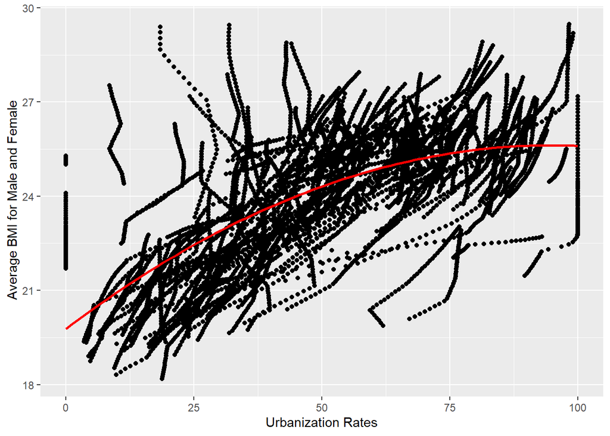

```r
library(ggplot2)
library(readxl)

InequalityBMI <- read_excel("C:/Users/SAN/Downloads/InequalityBMI Cleaned (1).xlsx")
View(InequalityBMI)

ggplot(InequalityBMI, aes(x = `Urbanization_Rates`, y = `Average_BMI`)) + geom_point() + geom_smooth( method = "lm", se=F, formula = 'y ~ poly(x, degree = 2, raw = T)', color = "red") + labs(x = "Urbanization Rates", y = " Average BMI for Male and Female")
```

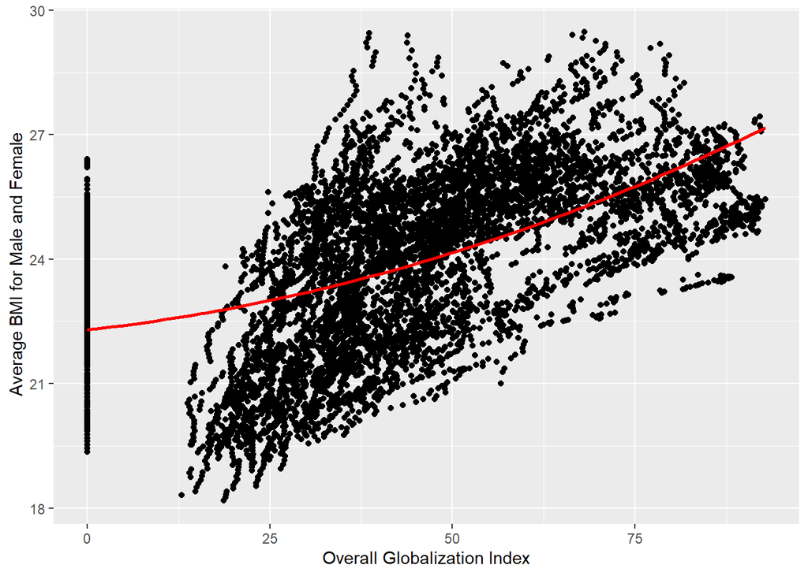

```r
ggplot(InequalityBMI, aes(x = `Overall_Globalization_Index`, y = `Average_BMI`)) + geom_point() + geom_smooth( method = "lm", se=F, formula = 'y ~ poly(x, degree = 2, raw = T)', color = "red") + labs(x = "Overall Globalization Index", y = " Average BMI for Male and Female")
```

The above scatter plot shows the relationship between Average BMI and Overall Globalization Index.

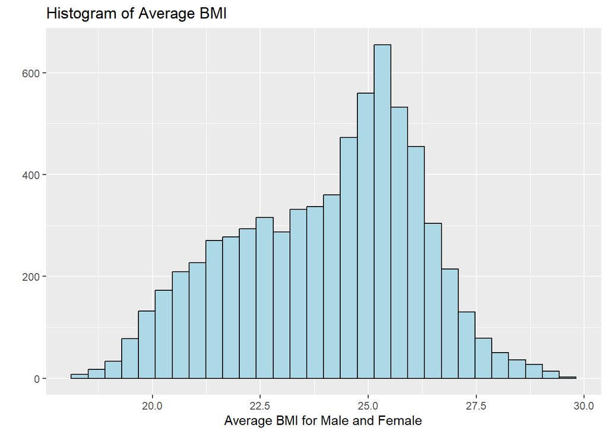

```r
ggplot(InequalityBMI, aes(x = Average_BMI)) +
  geom_histogram(fill = "lightblue", color = "black") +
  labs(title = "Histogram of Average BMI ",
       x = "Average BMI for Male and Female",
       y = "")
```

[figure not shown]

```r
ggplot(InequalityBMI, aes(x = `Population`, y = `Average_BMI`, fill = Population)) + geom_boxplot() + labs(x = "Overall Globalization Index", y = " Average BMI for Male and Female") + theme_minimal()
```

#### **IV. Methodology:**

##### **1. Presenting Model:**

In this project, we decided to use multiple linear regression to identify the association of GDP, Human Capital Index, Globalization Index, Urbanization Rate, Population on Average BMI. We run the model by following steps:

```r
# Loading the Dataset
library(readxl)
BMI <- read_excel("C:/Users/SAN/Downloads/InequalityBMI Cleaned (1).xlsx")
```

```r
# Cleaning up the Data to Run the Model
BMI <- BMI[,-4]
BMI <- BMI[,-3]
BMI$Country <- as.factor(BMI$Country)
str(BMI)
```

```
## tibble [6,880 × 10] (S3: tbl_df/tbl/data.frame)
##  $ Country                    : Factor w/ 172 levels "Albania","Algeria",..: 1 1 1 1 1 1 1 1 1 1 ...
##  $ Year                       : num [1:6880] 1975 1976 1977 1978 1979 ...
##  $ BMI_Male                   : num [1:6880] 24.7 24.8 24.8 24.9 24.9 ...
##  $ BMI_Female                 : num [1:6880] 25.8 25.8 25.8 25.8 25.8 ...
##  $ Average_BMI                : num [1:6880] 25.3 25.3 25.3 25.3 25.4 ...
##  $ Real_GDP                   : num [1:6880] 8762 9096 9488 9868 10175 ...
##  $ Population                 : num [1:6880] 2.41 2.46 2.52 2.57 2.63 ...
##  $ Human_Capital_Index        : num [1:6880] 1.7 1.74 1.77 1.81 1.84 ...
##  $ Urbanization_Rates         : num [1:6880] 32.7 32.9 33.1 33.3 33.5 ...
##  $ Overall_Globalization_Index: num [1:6880] 28.9 31.7 29.9 25.3 31.5 ...
```

```r
BMI$Country <- relevel(BMI$Country, ref = "United States of America")
```

```r
# Running the Model and Identifiying Collinearity among the Variables
model1 <- lm(Average_BMI ~ . - BMI_Male - BMI_Female, BMI)
summary(model1)
```

```
##
## Call:
## lm(formula = Average_BMI ~ . - BMI_Male - BMI_Female, data = BMI)
##
## Residuals:
##     Min      1Q  Median      3Q     Max
## -1.4415 -0.1311  0.0016  0.1306  1.6746
##
## Coefficients:
##                                           Estimate Std. Error  t value Pr(>|t|)
## (Intercept)                             -1.390e+02  1.078e+00 -128.933  < 2e-16
## CountryAlbania                          -1.817e+00  1.013e-01  -17.929  < 2e-16
## CountryAlgeria                          -3.618e+00  9.789e-02  -36.955  < 2e-16
## CountryAngola                           -6.006e+00  1.081e-01  -55.550  < 2e-16
## CountryAntigua and Barbuda              -2.735e+00  1.057e-01  -25.883  < 2e-16
## CountryArgentina                        -1.774e+00  9.613e-02  -18.451  < 2e-16
## CountryArmenia                          -2.851e+00  9.876e-02  -28.868  < 2e-16
## CountryAustralia                        -1.356e+00  9.490e-02  -14.290  < 2e-16
## CountryAustria                          -2.478e+00  9.617e-02  -25.769  < 2e-16
## CountryAzerbaijan                       -2.857e+00  1.017e-01  -28.097  < 2e-16
## CountryBahamas                          -2.559e+00  1.011e-01  -25.299  < 2e-16
## CountryBahrain                          -2.367e+00  9.831e-02  -24.079  < 2e-16
## CountryBangladesh                       -7.894e+00  1.104e-01  -71.518  < 2e-16
## CountryBarbados                         -1.286e+00  1.024e-01  -12.562  < 2e-16
## CountryBelarus                          -2.219e+00  1.004e-01  -22.103  < 2e-16
## CountryBelgium                          -2.064e+00  9.853e-02  -20.947  < 2e-16
## CountryBelize                           -7.419e-01  1.006e-01   -7.374 1.86e-13
## CountryBenin                            -6.118e+00  1.036e-01  -59.034  < 2e-16
## CountryBermuda                          -2.627e+00  1.029e-01  -25.542  < 2e-16
## CountryBhutan                           -5.587e+00  1.088e-01  -51.368  < 2e-16
## CountryBolivia                          -3.435e+00  9.844e-02  -34.892  < 2e-16
## CountryBosnia and Herzegovina           -2.811e+00  1.045e-01  -26.905  < 2e-16
## CountryBotswana                         -4.347e+00  1.010e-01  -43.061  < 2e-16
## CountryBrazil                           -3.083e+00  9.485e-02  -32.510  < 2e-16
## CountryBrunei Darussalam                -5.979e+00  9.755e-02  -61.295  < 2e-16
## CountryBulgaria                         -2.105e+00  9.696e-02  -21.706  < 2e-16
## CountryBurkina Faso                     -6.898e+00  1.092e-01  -63.185  < 2e-16
## CountryBurundi                          -7.189e+00  1.131e-01  -63.577  < 2e-16
## CountryCabo Verde                       -5.150e+00  1.030e-01  -50.007  < 2e-16
## CountryCambodia                         -7.405e+00  1.092e-01  -67.816  < 2e-16
```

[output cut: 318 more lines]

```
## CountryYemen                            ***
## CountryZambia                           ***
## CountryZimbabwe                         ***
## Year                                    ***
## Real_GDP                                *
## Population
## Human_Capital_Index                     ***
## Urbanization_Rates                      *
## Overall_Globalization_Index             ***
## ---
## Signif. codes:  0 '***' 0.001 '**' 0.01 '*' 0.05 '.' 0.1 ' ' 1
##
## Residual standard error: 0.2726 on 6702 degrees of freedom
## Multiple R-squared:  0.9841, Adjusted R-squared:  0.9837
## F-statistic:  2341 on 177 and 6702 DF,  p-value: < 2.2e-16
```

```r
cor(BMI[,-1])
```

```
##                                   Year   BMI_Male  BMI_Female Average_BMI
## Year                        1.00000000  0.3883183  0.36857012   0.3932749
## BMI_Male                    0.38831827  1.0000000  0.84777839   0.9578740
## BMI_Female                  0.36857012  0.8477784  1.00000000   0.9643756
## Average_BMI                 0.39327494  0.9578740  0.96437563   1.0000000
## Real_GDP                    0.11946306  0.1567054  0.06602817   0.1139187
## Population                  0.05145402 -0.1089077 -0.13489531  -0.1273695
## Human_Capital_Index         0.26638071  0.3579802  0.20034209   0.2870457
## Urbanization_Rates          0.17477146  0.6660910  0.54342543   0.6265122
## Overall_Globalization_Index 0.45903515  0.5761262  0.42824902   0.5192693
##                               Real_GDP  Population Human_Capital_Index
## Year                        0.11946306  0.05145402          0.26638071
## BMI_Male                    0.15670536 -0.10890770          0.35798021
## BMI_Female                  0.06602817 -0.13489531          0.20034209
## Average_BMI                 0.11391871 -0.12736950          0.28704573
## Real_GDP                    1.00000000  0.56292087          0.26216713
## Population                  0.56292087  1.00000000          0.08964054
## Human_Capital_Index         0.26216713  0.08964054          1.00000000
## Urbanization_Rates          0.16141569 -0.07155853          0.39547100
## Overall_Globalization_Index 0.24062727  0.04013189          0.63740243
##                             Urbanization_Rates Overall_Globalization_Index
## Year                                0.17477146                  0.45903515
## BMI_Male                            0.66609098                  0.57612623
## BMI_Female                          0.54342543                  0.42824902
## Average_BMI                         0.62651223                  0.51926932
## Real_GDP                            0.16141569                  0.24062727
## Population                         -0.07155853                  0.04013189
## Human_Capital_Index                 0.39547100                  0.63740243
## Urbanization_Rates                  1.00000000                  0.56867615
## Overall_Globalization_Index         0.56867615                  1.00000000
```

```r
library(car)
vif(model1)
```

```
##                                     GVIF  Df GVIF^(1/(2*Df))
## Country                     1.443739e+05 171        1.035348
## Year                        4.024246e+00   1        2.006052
## Real_GDP                    8.870821e+00   1        2.978392
## Population                  5.501115e+01   1        7.416950
## Human_Capital_Index         1.097179e+01   1        3.312370
## Urbanization_Rates          3.421240e+01   1        5.849136
## Overall_Globalization_Index 1.053223e+01   1        3.245340
```

When running VIF, and after adjusting GVIF for the variable Country that has more than one degree of freedom, results show that the variable Population has multicollinearity with other variables. Thus, we decided to remove it from our model to receive more accurate results.

```r
# Running the Model Without Population
model2 <- lm(Average_BMI ~ . - BMI_Male - BMI_Female - Population, BMI)
summary(model2)
```

```
##
## Call:
## lm(formula = Average_BMI ~ . - BMI_Male - BMI_Female - Population,
##     data = BMI)
##
## Residuals:
##      Min       1Q   Median       3Q      Max
## -1.44109 -0.13093  0.00157  0.13072  1.67464
##
## Coefficients:
##                                           Estimate Std. Error  t value Pr(>|t|)
## (Intercept)                             -1.390e+02  1.078e+00 -128.962  < 2e-16
## CountryAlbania                          -1.814e+00  1.012e-01  -17.927  < 2e-16
## CountryAlgeria                          -3.613e+00  9.749e-02  -37.060  < 2e-16
## CountryAngola                           -6.001e+00  1.077e-01  -55.715  < 2e-16
## CountryAntigua and Barbuda              -2.731e+00  1.055e-01  -25.900  < 2e-16
## CountryArgentina                        -1.770e+00  9.583e-02  -18.467  < 2e-16
## CountryArmenia                          -2.848e+00  9.864e-02  -28.877  < 2e-16
## CountryAustralia                        -1.355e+00  9.486e-02  -14.281  < 2e-16
## CountryAustria                          -2.476e+00  9.611e-02  -25.767  < 2e-16
## CountryAzerbaijan                       -2.853e+00  1.015e-01  -28.120  < 2e-16
## CountryBahamas                          -2.557e+00  1.011e-01  -25.299  < 2e-16
## CountryBahrain                          -2.366e+00  9.826e-02  -24.074  < 2e-16
## CountryBangladesh                       -7.878e+00  1.065e-01  -74.003  < 2e-16
## CountryBarbados                         -1.284e+00  1.023e-01  -12.551  < 2e-16
## CountryBelarus                          -2.216e+00  1.002e-01  -22.111  < 2e-16
## CountryBelgium                          -2.063e+00  9.850e-02  -20.941  < 2e-16
## CountryBelize                           -7.393e-01  1.005e-01   -7.357 2.11e-13
## CountryBenin                            -6.114e+00  1.034e-01  -59.141  < 2e-16
## CountryBermuda                          -2.625e+00  1.028e-01  -25.540  < 2e-16
## CountryBhutan                           -5.584e+00  1.085e-01  -51.446  < 2e-16
## CountryBolivia                          -3.432e+00  9.827e-02  -34.921  < 2e-16
## CountryBosnia and Herzegovina           -2.807e+00  1.042e-01  -26.928  < 2e-16
## CountryBotswana                         -4.345e+00  1.008e-01  -43.094  < 2e-16
## CountryBrazil                           -3.068e+00  9.038e-02  -33.944  < 2e-16
## CountryBrunei Darussalam                -5.977e+00  9.748e-02  -61.321  < 2e-16
## CountryBulgaria                         -2.102e+00  9.684e-02  -21.706  < 2e-16
## CountryBurkina Faso                     -6.893e+00  1.088e-01  -63.354  < 2e-16
## CountryBurundi                          -7.185e+00  1.127e-01  -63.725  < 2e-16
## CountryCabo Verde                       -5.147e+00  1.028e-01  -50.063  < 2e-16
```

[output cut: 317 more lines]

```
## CountryVietnam                          ***
## CountryYemen                            ***
## CountryZambia                           ***
## CountryZimbabwe                         ***
## Year                                    ***
## Real_GDP                                **
## Human_Capital_Index                     ***
## Urbanization_Rates                      *
## Overall_Globalization_Index             ***
## ---
## Signif. codes:  0 '***' 0.001 '**' 0.01 '*' 0.05 '.' 0.1 ' ' 1
##
## Residual standard error: 0.2726 on 6703 degrees of freedom
## Multiple R-squared:  0.9841, Adjusted R-squared:  0.9837
## F-statistic:  2355 on 176 and 6703 DF,  p-value: < 2.2e-16
```

```r
cor(BMI[,c(-1,-7)])
```

```
##                                  Year  BMI_Male BMI_Female Average_BMI
## Year                        1.0000000 0.3883183 0.36857012   0.3932749
## BMI_Male                    0.3883183 1.0000000 0.84777839   0.9578740
## BMI_Female                  0.3685701 0.8477784 1.00000000   0.9643756
## Average_BMI                 0.3932749 0.9578740 0.96437563   1.0000000
## Real_GDP                    0.1194631 0.1567054 0.06602817   0.1139187
## Human_Capital_Index         0.2663807 0.3579802 0.20034209   0.2870457
## Urbanization_Rates          0.1747715 0.6660910 0.54342543   0.6265122
## Overall_Globalization_Index 0.4590351 0.5761262 0.42824902   0.5192693
##                               Real_GDP Human_Capital_Index Urbanization_Rates
## Year                        0.11946306           0.2663807          0.1747715
## BMI_Male                    0.15670536           0.3579802          0.6660910
## BMI_Female                  0.06602817           0.2003421          0.5434254
## Average_BMI                 0.11391871           0.2870457          0.6265122
## Real_GDP                    1.00000000           0.2621671          0.1614157
## Human_Capital_Index         0.26216713           1.0000000          0.3954710
## Urbanization_Rates          0.16141569           0.3954710          1.0000000
## Overall_Globalization_Index 0.24062727           0.6374024          0.5686761
##                             Overall_Globalization_Index
## Year                                          0.4590351
## BMI_Male                                      0.5761262
## BMI_Female                                    0.4282490
## Average_BMI                                   0.5192693
## Real_GDP                                      0.2406273
## Human_Capital_Index                           0.6374024
## Urbanization_Rates                            0.5686761
## Overall_Globalization_Index                   1.0000000
```

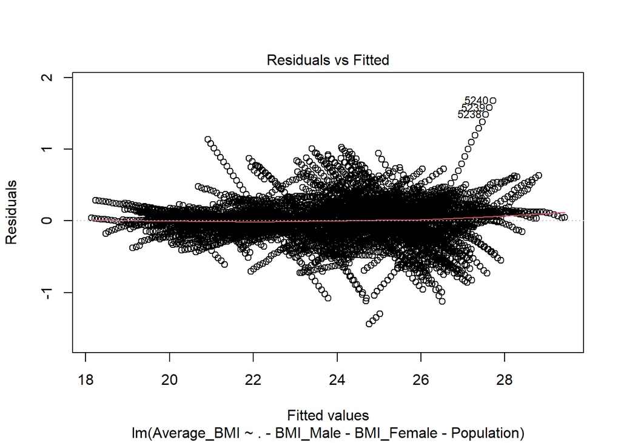

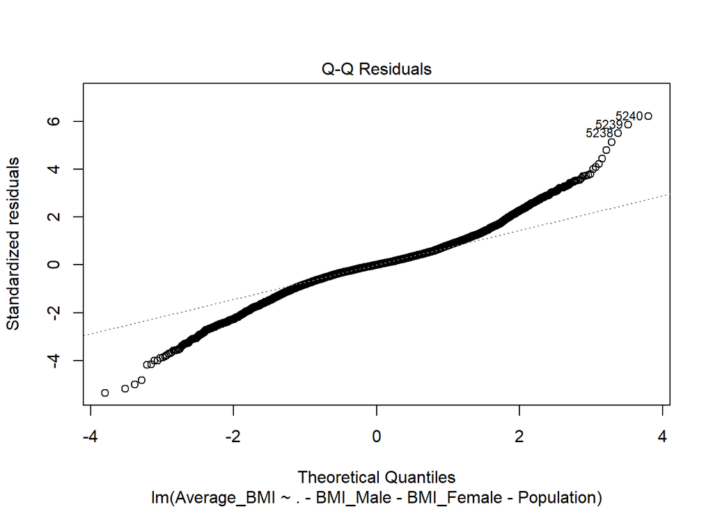

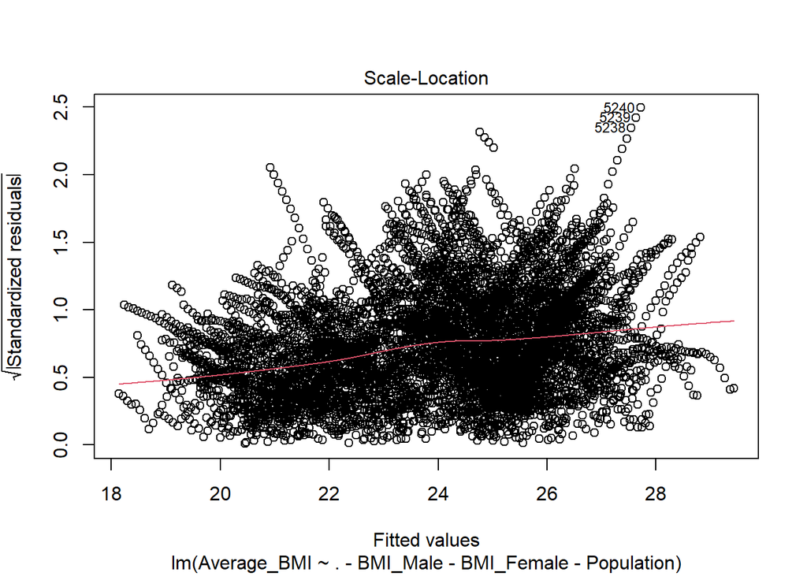

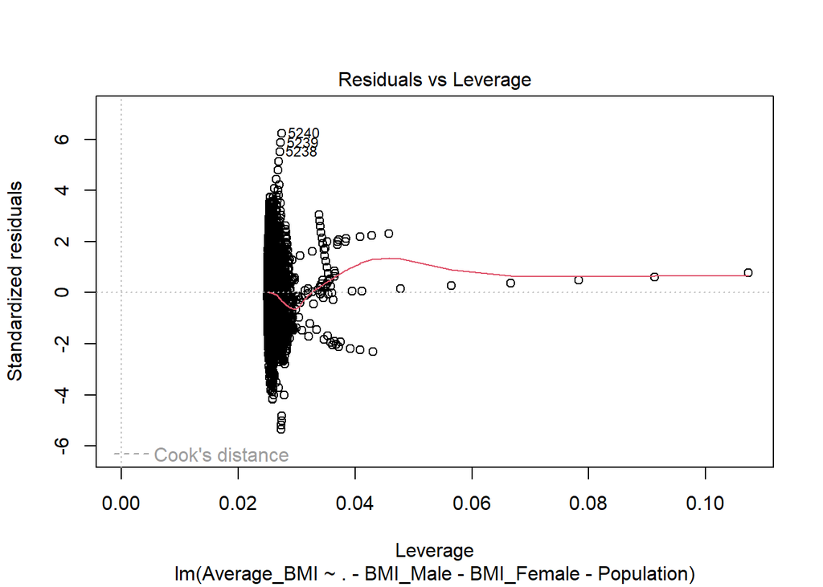

```r
# Testing for Nonlinear Association, Heterscedasticity, Outliers, and High leverage Points
plot(model2)
```

```r
# Removing the Outliers and Observing the Effects
BMI2 <- BMI[-c(5238,5239,5240,5237,5236,5235,5234,5233),]
model3 <- lm(Average_BMI ~ . - BMI_Male - BMI_Female - Population, BMI2)
summary(model3)
```

```
##
## Call:
## lm(formula = Average_BMI ~ . - BMI_Male - BMI_Female - Population,
##     data = BMI2)
##
## Residuals:
##      Min       1Q   Median       3Q      Max
## -1.11516 -0.12994  0.00039  0.13153  1.25238
##
## Coefficients:
##                                           Estimate Std. Error  t value Pr(>|t|)
## (Intercept)                             -1.372e+02  1.065e+00 -128.855  < 2e-16
## CountryAlbania                          -1.745e+00  9.942e-02  -17.547  < 2e-16
## CountryAlgeria                          -3.562e+00  9.576e-02  -37.197  < 2e-16
## CountryAngola                           -5.904e+00  1.059e-01  -55.745  < 2e-16
## CountryAntigua and Barbuda              -2.639e+00  1.037e-01  -25.447  < 2e-16
## CountryArgentina                        -1.771e+00  9.408e-02  -18.825  < 2e-16
## CountryArmenia                          -2.811e+00  9.687e-02  -29.019  < 2e-16
## CountryAustralia                        -1.362e+00  9.313e-02  -14.621  < 2e-16
## CountryAustria                          -2.452e+00  9.437e-02  -25.979  < 2e-16
## CountryAzerbaijan                       -2.791e+00  9.970e-02  -27.995  < 2e-16
## CountryBahamas                          -2.534e+00  9.922e-02  -25.542  < 2e-16
## CountryBahrain                          -2.366e+00  9.647e-02  -24.525  < 2e-16
## CountryBangladesh                       -7.776e+00  1.047e-01  -74.259  < 2e-16
## CountryBarbados                         -1.206e+00  1.005e-01  -12.000  < 2e-16
## CountryBelarus                          -2.172e+00  9.843e-02  -22.067  < 2e-16
## CountryBelgium                          -2.083e+00  9.671e-02  -21.536  < 2e-16
## CountryBelize                           -6.803e-01  9.873e-02   -6.890 6.08e-12
## CountryBenin                            -6.030e+00  1.016e-01  -59.336  < 2e-16
## CountryBermuda                          -2.632e+00  1.009e-01  -26.078  < 2e-16
## CountryBhutan                           -5.474e+00  1.068e-01  -51.275  < 2e-16
## CountryBolivia                          -3.386e+00  9.652e-02  -35.079  < 2e-16
## CountryBosnia and Herzegovina           -2.722e+00  1.025e-01  -26.561  < 2e-16
## CountryBotswana                         -4.275e+00  9.907e-02  -43.150  < 2e-16
## CountryBrazil                           -3.050e+00  8.874e-02  -34.371  < 2e-16
## CountryBrunei Darussalam                -5.948e+00  9.571e-02  -62.148  < 2e-16
## CountryBulgaria                         -2.075e+00  9.509e-02  -21.817  < 2e-16
## CountryBurkina Faso                     -6.781e+00  1.070e-01  -63.350  < 2e-16
## CountryBurundi                          -7.059e+00  1.110e-01  -63.613  < 2e-16
## CountryCabo Verde                       -5.073e+00  1.010e-01  -50.209  < 2e-16
```

[output cut: 317 more lines]

```
## CountryVietnam                          ***
## CountryYemen                            ***
## CountryZambia                           ***
## CountryZimbabwe                         ***
## Year                                    ***
## Real_GDP                                **
## Human_Capital_Index                     ***
## Urbanization_Rates
## Overall_Globalization_Index             ***
## ---
## Signif. codes:  0 '***' 0.001 '**' 0.01 '*' 0.05 '.' 0.1 ' ' 1
##
## Residual standard error: 0.2676 on 6695 degrees of freedom
## Multiple R-squared:  0.9846, Adjusted R-squared:  0.9842
## F-statistic:  2431 on 176 and 6695 DF,  p-value: < 2.2e-16
```

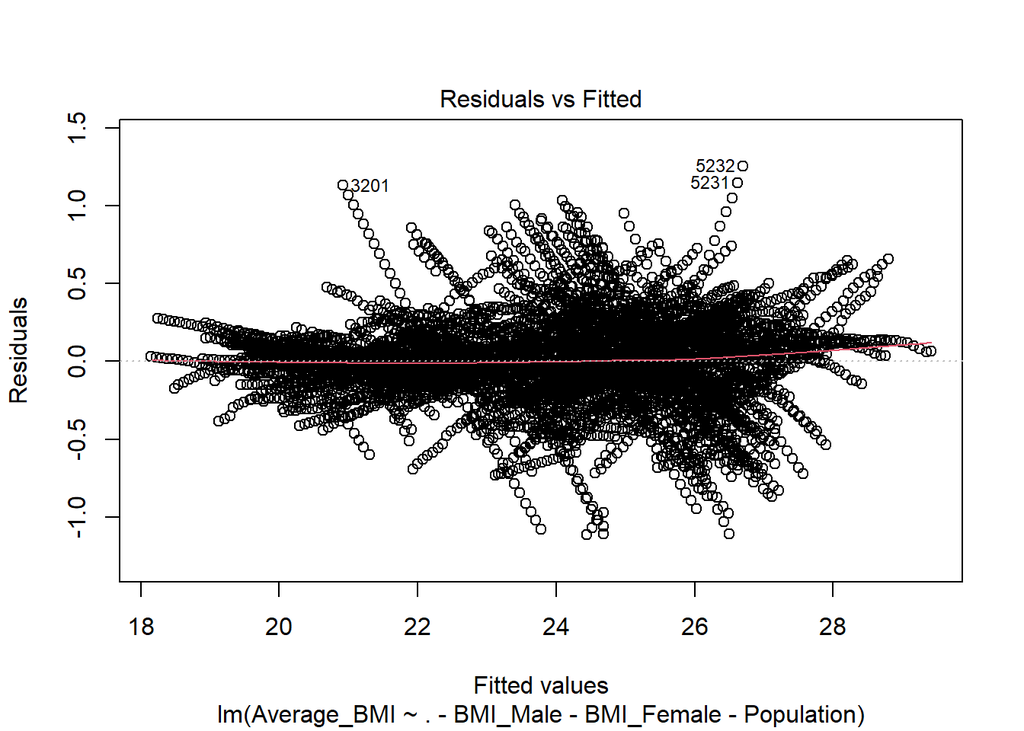

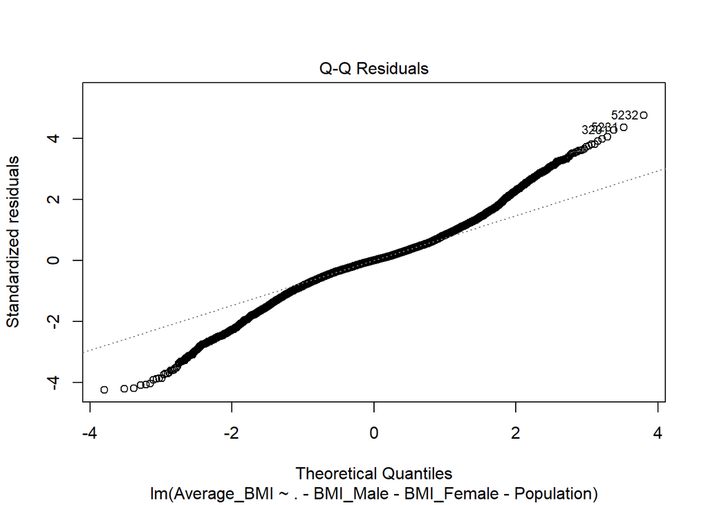

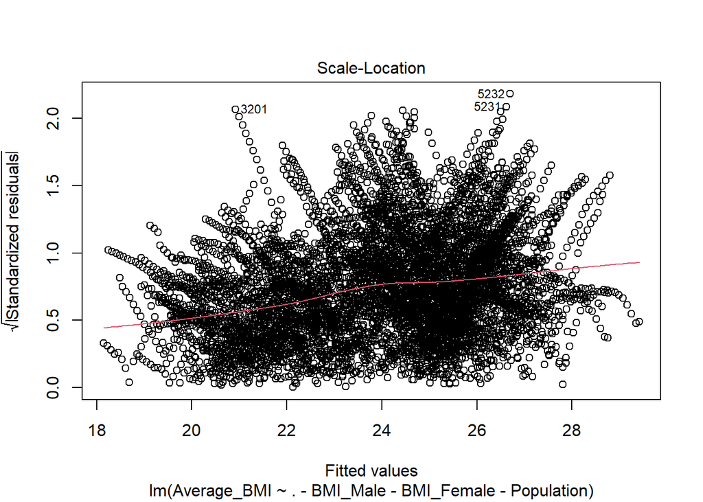

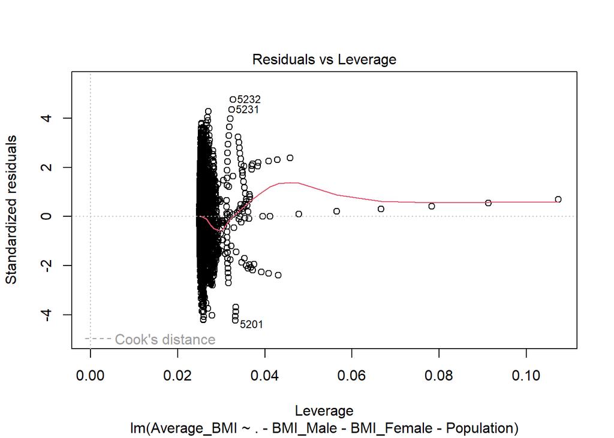

```r
plot(model3)
```

```r
vif(model3)
```

```
##                                    GVIF  Df GVIF^(1/(2*Df))
## Country                     4034.848600 171        1.024574
## Year                           4.064167   1        2.015978
## Real_GDP                       5.706441   1        2.388816
## Human_Capital_Index           10.928151   1        3.305775
## Urbanization_Rates            34.490697   1        5.872878
## Overall_Globalization_Index   10.517104   1        3.243009
```

We tried to remove the outliers and see if it can improve the results of the model, however the R-squared remained too high and the risduals graphs didn’t witness any significant changes.

```r
# Removing Country and Testing for Interaction Terms
BMI$Year <- as.factor(BMI$Year)
mod4 <- lm(Average_BMI ~ . - Country - BMI_Male - BMI_Female, BMI)
summary(mod4)
```

```
##
## Call:
## lm(formula = Average_BMI ~ . - Country - BMI_Male - BMI_Female,
##     data = BMI)
##
## Residuals:
##     Min      1Q  Median      3Q     Max
## -4.5217 -1.1137 -0.0376  1.0153  5.5862
##
## Coefficients:
##                               Estimate Std. Error t value Pr(>|t|)
## (Intercept)                  2.045e+01  1.214e-01 168.472  < 2e-16 ***
## Year1976                     4.412e-02  1.632e-01   0.270 0.786878
## Year1977                     8.865e-02  1.632e-01   0.543 0.586993
## Year1978                     1.329e-01  1.632e-01   0.814 0.415634
## Year1979                     1.723e-01  1.632e-01   1.056 0.291029
## Year1980                     2.194e-01  1.632e-01   1.344 0.178925
## Year1981                     2.616e-01  1.632e-01   1.602 0.109111
## Year1982                     3.156e-01  1.632e-01   1.934 0.053190 .
## Year1983                     3.631e-01  1.632e-01   2.225 0.026143 *
## Year1984                     4.099e-01  1.633e-01   2.511 0.012066 *
## Year1985                     4.580e-01  1.633e-01   2.805 0.005045 **
## Year1986                     5.103e-01  1.633e-01   3.125 0.001783 **
## Year1987                     5.660e-01  1.633e-01   3.466 0.000531 ***
## Year1988                     6.180e-01  1.633e-01   3.785 0.000155 ***
## Year1989                     6.689e-01  1.633e-01   4.096 4.25e-05 ***
## Year1990                     7.374e-01  1.634e-01   4.512 6.52e-06 ***
## Year1991                     7.365e-01  1.635e-01   4.504 6.78e-06 ***
## Year1992                     7.763e-01  1.636e-01   4.745 2.13e-06 ***
## Year1993                     8.106e-01  1.637e-01   4.951 7.55e-07 ***
## Year1994                     8.551e-01  1.638e-01   5.220 1.84e-07 ***
## Year1995                     8.938e-01  1.639e-01   5.452 5.16e-08 ***
## Year1996                     9.475e-01  1.640e-01   5.777 7.92e-09 ***
## Year1997                     9.937e-01  1.641e-01   6.054 1.49e-09 ***
## Year1998                     1.039e+00  1.643e-01   6.322 2.74e-10 ***
## Year1999                     1.084e+00  1.644e-01   6.595 4.58e-11 ***
## Year2000                     1.130e+00  1.646e-01   6.863 7.34e-12 ***
## Year2001                     1.186e+00  1.647e-01   7.203 6.51e-13 ***
## Year2002                     1.245e+00  1.647e-01   7.558 4.64e-14 ***
## Year2003                     1.296e+00  1.648e-01   7.865 4.26e-15 ***
## Year2004                     1.339e+00  1.650e-01   8.119 5.55e-16 ***
## Year2005                     1.394e+00  1.650e-01   8.448  < 2e-16 ***
## Year2006                     1.435e+00  1.652e-01   8.690  < 2e-16 ***
## Year2007                     1.477e+00  1.653e-01   8.932  < 2e-16 ***
## Year2008                     1.534e+00  1.653e-01   9.281  < 2e-16 ***
## Year2009                     1.590e+00  1.653e-01   9.619  < 2e-16 ***
## Year2010                     1.638e+00  1.654e-01   9.900  < 2e-16 ***
## Year2011                     1.691e+00  1.654e-01  10.226  < 2e-16 ***
## Year2012                     1.740e+00  1.654e-01  10.520  < 2e-16 ***
## Year2013                     1.790e+00  1.655e-01  10.819  < 2e-16 ***
## Year2014                     1.834e+00  1.656e-01  11.074  < 2e-16 ***
## Real_GDP                     1.209e-07  2.045e-08   5.909 3.61e-09 ***
## Population                  -2.470e-03  1.875e-04 -13.172  < 2e-16 ***
## Human_Capital_Index         -1.723e-01  2.216e-02  -7.777 8.55e-15 ***
## Urbanization_Rates           4.485e-02  9.480e-04  47.316  < 2e-16 ***
## Overall_Globalization_Index  1.597e-02  1.340e-03  11.916  < 2e-16 ***
## ---
## Signif. codes:  0 '***' 0.001 '**' 0.01 '*' 0.05 '.' 0.1 ' ' 1
##
## Residual standard error: 1.513 on 6835 degrees of freedom
## Multiple R-squared:  0.4998, Adjusted R-squared:  0.4966
## F-statistic: 155.2 on 44 and 6835 DF,  p-value: < 2.2e-16
```

```r
library(car)
vif(mod4)
```

```
##                                 GVIF Df GVIF^(1/(2*Df))
## Year                        1.318397 39        1.003550
## Real_GDP                    1.620558  1        1.273011
## Population                  1.526409  1        1.235479
## Human_Capital_Index         1.738047  1        1.318350
## Urbanization_Rates          1.550350  1        1.245131
## Overall_Globalization_Index 2.554800  1        1.598374
```

```r
BMI$Year <- as.factor(BMI$Year)
model4 <- lm(Average_BMI ~ . - Country - BMI_Male - BMI_Female + Human_Capital_Index*Real_GDP, BMI)
summary(model4)
```

```
##
## Call:
## lm(formula = Average_BMI ~ . - Country - BMI_Male - BMI_Female +
##     Human_Capital_Index * Real_GDP, data = BMI)
##
## Residuals:
##     Min      1Q  Median      3Q     Max
## -4.4157 -1.1169 -0.0407  1.0192  5.5949
##
## Coefficients:
##                                Estimate Std. Error t value Pr(>|t|)
## (Intercept)                   2.045e+01  1.213e-01 168.566  < 2e-16 ***
## Year1976                      4.415e-02  1.631e-01   0.271 0.786660
## Year1977                      8.879e-02  1.631e-01   0.544 0.586236
## Year1978                      1.332e-01  1.631e-01   0.817 0.414230
## Year1979                      1.726e-01  1.631e-01   1.058 0.290000
## Year1980                      2.198e-01  1.631e-01   1.347 0.177882
## Year1981                      2.626e-01  1.632e-01   1.609 0.107558
## Year1982                      3.175e-01  1.632e-01   1.946 0.051697 .
## Year1983                      3.656e-01  1.632e-01   2.240 0.025094 *
## Year1984                      4.124e-01  1.632e-01   2.527 0.011511 *
## Year1985                      4.606e-01  1.632e-01   2.823 0.004777 **
## Year1986                      5.137e-01  1.632e-01   3.147 0.001655 **
## Year1987                      5.693e-01  1.632e-01   3.488 0.000490 ***
## Year1988                      6.214e-01  1.632e-01   3.807 0.000142 ***
## Year1989                      6.725e-01  1.632e-01   4.120 3.84e-05 ***
## Year1990                      7.385e-01  1.634e-01   4.521 6.26e-06 ***
## Year1991                      7.384e-01  1.635e-01   4.517 6.37e-06 ***
## Year1992                      7.785e-01  1.635e-01   4.761 1.97e-06 ***
## Year1993                      8.133e-01  1.636e-01   4.970 6.85e-07 ***
## Year1994                      8.580e-01  1.637e-01   5.240 1.65e-07 ***
## Year1995                      8.965e-01  1.639e-01   5.471 4.64e-08 ***
## Year1996                      9.500e-01  1.639e-01   5.795 7.15e-09 ***
## Year1997                      9.964e-01  1.641e-01   6.073 1.32e-09 ***
## Year1998                      1.042e+00  1.642e-01   6.347 2.34e-10 ***
## Year1999                      1.088e+00  1.644e-01   6.622 3.82e-11 ***
## Year2000                      1.134e+00  1.645e-01   6.890 6.10e-12 ***
## Year2001                      1.190e+00  1.646e-01   7.231 5.30e-13 ***
## Year2002                      1.249e+00  1.646e-01   7.585 3.77e-14 ***
## Year2003                      1.300e+00  1.647e-01   7.892 3.45e-15 ***
```

[output cut: 8 more lines]

```
## Year2012                      1.733e+00  1.654e-01  10.479  < 2e-16 ***
## Year2013                      1.782e+00  1.654e-01  10.775  < 2e-16 ***
## Year2014                      1.826e+00  1.655e-01  11.031  < 2e-16 ***
## Real_GDP                      5.108e-07  1.466e-07   3.483 0.000498 ***
## Population                   -3.089e-03  2.972e-04 -10.395  < 2e-16 ***
## Human_Capital_Index          -1.691e-01  2.218e-02  -7.624 2.80e-14 ***
## Urbanization_Rates            4.459e-02  9.525e-04  46.815  < 2e-16 ***
## Overall_Globalization_Index   1.587e-02  1.340e-03  11.847  < 2e-16 ***
## Real_GDP:Human_Capital_Index -1.106e-07  4.119e-08  -2.685 0.007263 **
## ---
## Signif. codes:  0 '***' 0.001 '**' 0.01 '*' 0.05 '.' 0.1 ' ' 1
##
## Residual standard error: 1.513 on 6834 degrees of freedom
## Multiple R-squared:  0.5004, Adjusted R-squared:  0.4971
## F-statistic: 152.1 on 45 and 6834 DF,  p-value: < 2.2e-16
```

After testing to remove some variables from the model, we found that the variable Country was related to the high R-squared value, and as such we decided to remove it to produce a more valid model. Then, we tested some interaction terms and found that Human_Capital_Index*Real_GDP is the interaction term that improves the R-squared the most, reaching 49.71%. However, there wasn’t any reasonable explanation for the interaction term. As such, we next tested some polynomial variables to study the effects on the model.

```r
# Removing Country and Testing for Polynomial Terms
BMI$Year <- as.factor(BMI$Year)
model5 <- lm(Average_BMI ~ . - Human_Capital_Index - Country - BMI_Male - BMI_Female + poly(Human_Capital_Index, degree = 4, raw = TRUE), BMI)
summary(model5)
```

```
##
## Call:
## lm(formula = Average_BMI ~ . - Human_Capital_Index - Country -
##     BMI_Male - BMI_Female + poly(Human_Capital_Index, degree = 4,
##     raw = TRUE), data = BMI)
##
## Residuals:
##     Min      1Q  Median      3Q     Max
## -4.1940 -0.8428  0.0071  0.8826  4.8697
##
## Coefficients:
##                                                      Estimate Std. Error
## (Intercept)                                         2.187e+01  1.192e-01
## Year1976                                            3.078e-02  1.493e-01
## Year1977                                            6.199e-02  1.493e-01
## Year1978                                            9.334e-02  1.493e-01
## Year1979                                            1.206e-01  1.494e-01
## Year1980                                            1.558e-01  1.494e-01
## Year1981                                            1.795e-01  1.494e-01
## Year1982                                            2.145e-01  1.494e-01
## Year1983                                            2.440e-01  1.494e-01
## Year1984                                            2.736e-01  1.495e-01
## Year1985                                            3.053e-01  1.495e-01
## Year1986                                            3.438e-01  1.495e-01
## Year1987                                            3.860e-01  1.495e-01
## Year1988                                            4.254e-01  1.495e-01
## Year1989                                            4.779e-01  1.495e-01
## Year1990                                            5.239e-01  1.497e-01
## Year1991                                            5.142e-01  1.498e-01
## Year1992                                            5.419e-01  1.499e-01
## Year1993                                            5.652e-01  1.500e-01
## Year1994                                            5.985e-01  1.501e-01
## Year1995                                            6.272e-01  1.502e-01
## Year1996                                            6.719e-01  1.503e-01
## Year1997                                            7.103e-01  1.504e-01
## Year1998                                            7.481e-01  1.506e-01
## Year1999                                            7.875e-01  1.507e-01
## Year2000                                            8.269e-01  1.509e-01
## Year2001                                            8.777e-01  1.509e-01
## Year2002                                            9.310e-01  1.510e-01
```

[output cut: 60 more lines]

```
## Year2014                                             9.619  < 2e-16 ***
## Real_GDP                                             5.122 3.10e-07 ***
## Population                                         -13.863  < 2e-16 ***
## Urbanization_Rates                                  31.144  < 2e-16 ***
## Overall_Globalization_Index                         11.801  < 2e-16 ***
## poly(Human_Capital_Index, degree = 4, raw = TRUE)1 -26.748  < 2e-16 ***
## poly(Human_Capital_Index, degree = 4, raw = TRUE)2  22.087  < 2e-16 ***
## poly(Human_Capital_Index, degree = 4, raw = TRUE)3 -18.629  < 2e-16 ***
## poly(Human_Capital_Index, degree = 4, raw = TRUE)4  15.891  < 2e-16 ***
## ---
## Signif. codes:  0 '***' 0.001 '**' 0.01 '*' 0.05 '.' 0.1 ' ' 1
##
## Residual standard error: 1.385 on 6832 degrees of freedom
## Multiple R-squared:  0.5814, Adjusted R-squared:  0.5785
## F-statistic: 201.9 on 47 and 6832 DF,  p-value: < 2.2e-16
```

```r
vif(model5)
```

```
##                                                       GVIF Df GVIF^(1/(2*Df))
## Year                                              1.368692 39        1.004032
## Real_GDP                                          1.906900  1        1.380905
## Population                                        1.625672  1        1.275018
## Urbanization_Rates                                1.903981  1        1.379848
## Overall_Globalization_Index                       2.643870  1        1.625998
## poly(Human_Capital_Index, degree = 4, raw = TRUE) 3.132391  4        1.153412
```

Testing for polynomial terms landed a better R-squared, reaching 57.85%. While checking for collinearity produced favorable results as no variable is correlated to other variables.

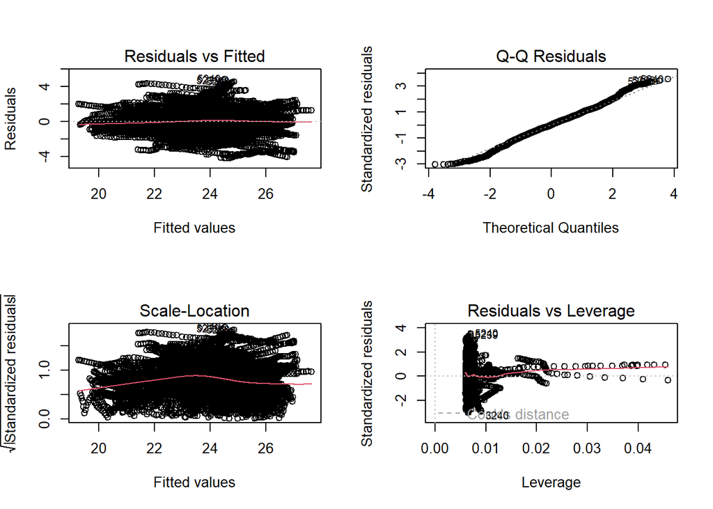

```r
# Checking The Risudal Graphs for any Issues
par(mfrow = c(2, 2))
plot(model5)
```

The graphs shows that model5 retained the linear relationship between the outcome variable and the predictors as tested previously. Q-Q Risduals graph shows significant improvement after adding the polynomial terms to the model. Scale location still shows that there is no heteroscedasticity as the data points are still relatively evenly scattered. Finally, Risduals vs. Leverage graph shows still shows no high leverage points that might affect the validity of the model since no point exceeds cook’s distance. However, the model captures the non-linear relationship between Human capital index and Average BMI, as evident by the variation in the slope amount between each degree in the polynomial term.

##### **2.Practical Considerations:**

**Availability of data**: The data consist of both categorical time-related variables (e.g., years) and continuous variables (e.g., GDP, Population, Urbanization Rates). For handling this kind of mixed data, multiple linear regression works well.

**Linear Regression vs. Logistic Regression**: Since the outcome variable is the average BMI, which is continuous rather than binary outcome, logistic regression would not be appropriately used in this case.

**Time-series variable**: The model accounts for temporal trends in Average BMI with the year variable as categorical predictor, contributing significant dimension to the analysis. When analyzing a model which includes economic variables, particularly time effect is significant, this model is a standard approach.

**Previous research**: Linear regression models are utilized in health economics and demographics study to analyze public health data and develop healthcare interventions.For example, the Income and obesity in an urban poor community: a cross-sectional study carried out by Harvard Dataverse analyzed the relationship between low-high income countries and obesity among residents in an urban community. They also used linear regression to identify BMI predictors and investigate the association of those variables.

##### **3. Approach and Methodology**

**Justify Model selection**:

Multiple linear regression model is chosen in this study based on following reasons:

**Complexity of problems**: The dataset include 6880 observations with 10 variables which make multiple linear regression well-suited to idenitfy relationship between those variables. The goal is to determine interaction and contribution of several variables such as GDP, Human Capital Index, Globalization Index, Urbanization Rate, Population on Average BMI on a country-level.

**High compatibility**: This dataset contains both numerical and categorical variables to examine the data for country-level analysis. Multiple linear regression can effectively handles these types of variables by using dummy variables.

**Interpretation**: It’s simply easy to comprehend how each predictor affects the outcome variable - Average BMI - when using multiple linear regression models, which aligns closely with our research question in investigating impact of those variables on BMI.

Additionally, multiple regression consists of several considerations and principle including **interaction term**,**Hierarchical principle**, **Variance Inflation Factor (VIF)** and **diagnostic plots** to which we can utilize to validate our result.

**Interaction term** studies any synergy effects of two predictors which might jointly affect BMI of several countries. If any non-linear relationship exists, we can utilize **polynomial regression** to extend the relationship to achieve a better fit model. In this case, our R-squared reached 57% which implies 57% of average BMI can be explained by variables.

Therefore, it is effectively utilized in this study to address the research question in investigating what economic and socidemographic factors influence BMI on a country-level. We assume that Globalization Index, Human Capital Index, Year and Urbanization Rate have a linear contribution on BMI, making this model an optimal selection to determine the strength and interpretation of how predictors contribute to BMI.

##### **Preprocessing**:

**Data Transformation**: This dataset includes specific BMI for both male and female, we created a new variable called Average BMI variable which calculate the average BMI for both male and female to improve intergration, insightful interpretation and analysis.

**Dummy Encoding:** Convert the categorical **Year** variable into binary dummy variables to include in the regression model which allows us to analyze country-specific effects while maintaining the linear form of the model.

**Feature Engineering:**  
**Dummy variables**: The year variables is characterized as categorical variables and it’s will be converted into dummy variables to enhance the analysis.

##### **Model training/validation**:

**Variance Inflation Factor (VIF)**: We utilize VIF to check the multicollinearity of multiple variables to guarantee the accuracy of analysis. In this case, we investigate our variables are largely independent to other variables since their VIF are from 1 to 3 which are generally accepted due to their moderate correlation.

**Model Fit:** R-squared and ajusted R-squared are used to determine the fitness of model which provide 57%of Average BMI can be explained by independent variables.

**Unique Features and Advantages of the Model**:

**Flexibility - Polynomial Regression**: This model can be extended by addition features of mutilple linear regression: To capture nonlinear relationship of human capital index, we use polynomial term and figured out degree 4 is significant to the model which increased the R-squared of model from 49% to 57%.

Interpreting the key findings for the model, the model predicts Average BMI and the predictors are Year, Real GDP, Human Capital Index, Urbanization rates, Population and Overall Globalization Index.

##### **Key results**:

**1. Intercept:**  
The Estimate is 21.87, represents the Average BMI when all other variables are zero.

**2. Year Variable:** Year is dummy variables represent the effects of each specific year with the estimated difference in Average_BMI compared to a reference year (1975).Years 1985-2014 have a significant positive impact on BMI, indicating a trend of increasing BMI over the years.

**3. Real GDP:**  
The Estimate is 1.04e-07, positive and statistically significant coefficient for Real GDP (p < 0.001) suggests that as a country’s GDP increases, so does the Average BMI. However, since the coefficient is very small, the impact of Real_GDP on Average_BMI is minimal but statistically significant.

**4. Population:**  
The Estimate is -2.455e-03, population has a statistically significant negative impact on BMI. As population size increases, the average BMI slightly decreases.While there seems to be a weak inverse relationship, it’s likely influenced by population differences across countries.

**5. Urbanization Rates:**  
The Estimate is 2.994e-02, the Urbanization Rates variable is significant (p < 0.001), and its positive coefficient suggests that more urbanized regions tend to have higher BMIs.Urban areas often show higher average BMI, likely influenced by city living habits—think sedentary lifestyles and dietary shifts.

**6. Overall_Globalization_Index:**  
The Estimate is 1.472e-02, A positive and statistically significant coefficient for the Globalization Index suggests that as countries become more globalized, average BMI increases.

**7. Human_Capital_Index:**  
The inclusion of a 4th-degree polynomial for the Human Capital Index suggests a complex, nonlinear relationship between human capital and BMI.  
First degree poly (negative):The Estimate is -1.001e+01, Suggests an initial decrease in BMI with increases in human capital.  
Second degree poly(positive):The Estimate is 1.075e+01,Reverses the trend, suggesting that beyond a certain point, increases in human capital lead to higher BMI.  
Third degree poly(negative):The Estimate is -3.804e+00,Introduces further complexity, suggesting additional curvature in the relationship.  
Fourth degree poly(positive):The Estimate is 4.391e-01,Continues this pattern, confirming the model’s flexibility in capturing a nuanced relationship between human capital and BMI.

##### **Conclusion:**

The model shows a clear trend of increasing Average BMI over time, with later years significantly contributing to the rise. Real GDP has a small positive impact, while Population has a slight negative effect on BMI. The Human Capital Index exhibits a strong nonlinear influence, generally reducing BMI as it increases, but with more complexity captured by the polynomial terms. Both Urbanization Rates and the Globalization Index have small but significant positive effects on BMI. Overall, the model provides a comprehensive view of how socio-economic and demographic factors influence BMI, highlighting both positive and negative contributors.

The research aimed to understand the socio-economic and demographic drivers of Average BMI globally. Real GDP shows a positive impact on BMI, indicating that economic growth contributes to weight gain. The nonlinear relationship of Human Capital Index suggests a more complex interaction between how well countries are investing in the health and education of their people and BMI, with overall reductions in BMI at higher levels of human capital index.

#### **VI. Evaluating the Model’s Performance and Discussing Its Advantages and Weaknesses:**

After testing several models, we landed on model5 which included the polynomial term for Human Capital Index and removing the variable Country which was causing the overfitting issue in the previous models. The model validates our study’s assumption on the influence of socio-demographic factors on BMI, and results show that the factors year, population, real GDP, Human Capital Index (HCI), urbanization rates, and Overall Globalization Index have a statistically significant relationship with the outcome variable BMI, since the p-value was significant for all these variables our model.

Our model shows that the aforementioned factors has 57.85% influence on BMI’s results, and although this is a significant relationship, it’s still not perfect. Moreover, the added polynomial term captures the complex relationship between HCI and BMI, as they have a non-linear relationship indicated by the resulting slope for each degree in the model.